# Risk Factor Analysis

## Outcome Variable

**Outcome Variable:** swasted

## Predictor Variables

**Intervention Variable:** brthmon

**Adjustment Set:**

unadjusted

## Stratifying Variables

The analysis was stratified on these variable(s):

- agecat
- studyid
- country

## Data Summary

| agecat | studyid | country | brthmon | swasted | n_cell | n |
| --- | --- | --- | --- | --- | --- | --- |
| Birth | CMC-V-BCS-2002 | INDIA | 1 | 0 | 9 | 86 |
| Birth | CMC-V-BCS-2002 | INDIA | 1 | 1 | 0 | 86 |
| Birth | CMC-V-BCS-2002 | INDIA | 2 | 0 | 1 | 86 |
| Birth | CMC-V-BCS-2002 | INDIA | 2 | 1 | 0 | 86 |
| Birth | CMC-V-BCS-2002 | INDIA | 3 | 0 | 7 | 86 |
| Birth | CMC-V-BCS-2002 | INDIA | 3 | 1 | 0 | 86 |
| Birth | CMC-V-BCS-2002 | INDIA | 4 | 0 | 9 | 86 |
| Birth | CMC-V-BCS-2002 | INDIA | 4 | 1 | 0 | 86 |
| Birth | CMC-V-BCS-2002 | INDIA | 5 | 0 | 10 | 86 |
| Birth | CMC-V-BCS-2002 | INDIA | 5 | 1 | 0 | 86 |
| Birth | CMC-V-BCS-2002 | INDIA | 6 | 0 | 9 | 86 |
| Birth | CMC-V-BCS-2002 | INDIA | 6 | 1 | 0 | 86 |
| Birth | CMC-V-BCS-2002 | INDIA | 7 | 0 | 7 | 86 |
| Birth | CMC-V-BCS-2002 | INDIA | 7 | 1 | 0 | 86 |
| Birth | CMC-V-BCS-2002 | INDIA | 8 | 0 | 4 | 86 |
| Birth | CMC-V-BCS-2002 | INDIA | 8 | 1 | 0 | 86 |
| Birth | CMC-V-BCS-2002 | INDIA | 9 | 0 | 7 | 86 |
| Birth | CMC-V-BCS-2002 | INDIA | 9 | 1 | 1 | 86 |
| Birth | CMC-V-BCS-2002 | INDIA | 10 | 0 | 8 | 86 |
| Birth | CMC-V-BCS-2002 | INDIA | 10 | 1 | 0 | 86 |
| Birth | CMC-V-BCS-2002 | INDIA | 11 | 0 | 11 | 86 |
| Birth | CMC-V-BCS-2002 | INDIA | 11 | 1 | 0 | 86 |
| Birth | CMC-V-BCS-2002 | INDIA | 12 | 0 | 3 | 86 |
| Birth | CMC-V-BCS-2002 | INDIA | 12 | 1 | 0 | 86 |
| Birth | CMIN | BANGLADESH | 1 | 0 | 2 | 19 |
| Birth | CMIN | BANGLADESH | 1 | 1 | 0 | 19 |
| Birth | CMIN | BANGLADESH | 2 | 0 | 4 | 19 |
| Birth | CMIN | BANGLADESH | 2 | 1 | 0 | 19 |
| Birth | CMIN | BANGLADESH | 3 | 0 | 0 | 19 |
| Birth | CMIN | BANGLADESH | 3 | 1 | 0 | 19 |

[output cut: 1650 more lines]

The following strata were considered:

- agecat: 24 months, studyid: CMC-V-BCS-2002, country: INDIA
- agecat: 24 months, studyid: CMIN, country: BANGLADESH
- agecat: 24 months, studyid: CONTENT, country: PERU
- agecat: 24 months, studyid: EE, country: PAKISTAN
- agecat: 24 months, studyid: GMS-Nepal, country: NEPAL
- agecat: 24 months, studyid: IRC, country: INDIA
- agecat: 24 months, studyid: JiVitA-3, country: BANGLADESH
- agecat: 24 months, studyid: JiVitA-4, country: BANGLADESH
- agecat: 24 months, studyid: Keneba, country: GAMBIA
- agecat: 24 months, studyid: LCNI-5, country: MALAWI
- agecat: 24 months, studyid: MAL-ED, country: BANGLADESH
- agecat: 24 months, studyid: MAL-ED, country: BRAZIL
- agecat: 24 months, studyid: MAL-ED, country: INDIA
- agecat: 24 months, studyid: MAL-ED, country: NEPAL
- agecat: 24 months, studyid: MAL-ED, country: PERU
- agecat: 24 months, studyid: MAL-ED, country: SOUTH AFRICA
- agecat: 24 months, studyid: MAL-ED, country: TANZANIA, UNITED REPUBLIC OF
- agecat: 24 months, studyid: NIH-Birth, country: BANGLADESH
- agecat: 24 months, studyid: PROBIT, country: BELARUS
- agecat: 24 months, studyid: PROVIDE, country: BANGLADESH
- agecat: 24 months, studyid: TanzaniaChild2, country: TANZANIA, UNITED REPUBLIC OF
- agecat: 24 months, studyid: ZVITAMBO, country: ZIMBABWE
- agecat: 6 months, studyid: CMC-V-BCS-2002, country: INDIA
- agecat: 6 months, studyid: CMIN, country: BANGLADESH
- agecat: 6 months, studyid: CONTENT, country: PERU
- agecat: 6 months, studyid: EE, country: PAKISTAN
- agecat: 6 months, studyid: GMS-Nepal, country: NEPAL
- agecat: 6 months, studyid: Guatemala BSC, country: GUATEMALA
- agecat: 6 months, studyid: IRC, country: INDIA
- agecat: 6 months, studyid: JiVitA-3, country: BANGLADESH
- agecat: 6 months, studyid: JiVitA-4, country: BANGLADESH
- agecat: 6 months, studyid: Keneba, country: GAMBIA
- agecat: 6 months, studyid: LCNI-5, country: MALAWI
- agecat: 6 months, studyid: MAL-ED, country: BANGLADESH
- agecat: 6 months, studyid: MAL-ED, country: BRAZIL
- agecat: 6 months, studyid: MAL-ED, country: INDIA
- agecat: 6 months, studyid: MAL-ED, country: NEPAL
- agecat: 6 months, studyid: MAL-ED, country: PERU
- agecat: 6 months, studyid: MAL-ED, country: SOUTH AFRICA
- agecat: 6 months, studyid: MAL-ED, country: TANZANIA, UNITED REPUBLIC OF
- agecat: 6 months, studyid: NIH-Birth, country: BANGLADESH
- agecat: 6 months, studyid: PROBIT, country: BELARUS
- agecat: 6 months, studyid: PROVIDE, country: BANGLADESH
- agecat: 6 months, studyid: ResPak, country: PAKISTAN
- agecat: 6 months, studyid: SAS-CompFeed, country: INDIA
- agecat: 6 months, studyid: SAS-FoodSuppl, country: INDIA
- agecat: 6 months, studyid: TanzaniaChild2, country: TANZANIA, UNITED REPUBLIC OF
- agecat: 6 months, studyid: ZVITAMBO, country: ZIMBABWE
- agecat: Birth, studyid: CMC-V-BCS-2002, country: INDIA
- agecat: Birth, studyid: CMIN, country: BANGLADESH
- agecat: Birth, studyid: CONTENT, country: PERU
- agecat: Birth, studyid: EE, country: PAKISTAN
- agecat: Birth, studyid: GMS-Nepal, country: NEPAL
- agecat: Birth, studyid: IRC, country: INDIA
- agecat: Birth, studyid: JiVitA-3, country: BANGLADESH
- agecat: Birth, studyid: JiVitA-4, country: BANGLADESH
- agecat: Birth, studyid: Keneba, country: GAMBIA
- agecat: Birth, studyid: MAL-ED, country: BANGLADESH
- agecat: Birth, studyid: MAL-ED, country: BRAZIL
- agecat: Birth, studyid: MAL-ED, country: INDIA
- agecat: Birth, studyid: MAL-ED, country: NEPAL
- agecat: Birth, studyid: MAL-ED, country: PERU
- agecat: Birth, studyid: MAL-ED, country: SOUTH AFRICA
- agecat: Birth, studyid: MAL-ED, country: TANZANIA, UNITED REPUBLIC OF
- agecat: Birth, studyid: NIH-Birth, country: BANGLADESH
- agecat: Birth, studyid: PROBIT, country: BELARUS
- agecat: Birth, studyid: PROVIDE, country: BANGLADESH
- agecat: Birth, studyid: ResPak, country: PAKISTAN
- agecat: Birth, studyid: SAS-CompFeed, country: INDIA
- agecat: Birth, studyid: ZVITAMBO, country: ZIMBABWE

### Dropped Strata

Some strata were dropped due to rare outcomes:

- agecat: Birth, studyid: CMC-V-BCS-2002, country: INDIA
- agecat: Birth, studyid: CMIN, country: BANGLADESH
- agecat: Birth, studyid: CONTENT, country: PERU
- agecat: Birth, studyid: EE, country: PAKISTAN
- agecat: Birth, studyid: GMS-Nepal, country: NEPAL
- agecat: Birth, studyid: IRC, country: INDIA
- agecat: Birth, studyid: JiVitA-4, country: BANGLADESH
- agecat: Birth, studyid: Keneba, country: GAMBIA
- agecat: Birth, studyid: MAL-ED, country: BANGLADESH
- agecat: Birth, studyid: MAL-ED, country: BRAZIL
- agecat: Birth, studyid: MAL-ED, country: INDIA
- agecat: Birth, studyid: MAL-ED, country: NEPAL
- agecat: Birth, studyid: MAL-ED, country: PERU
- agecat: Birth, studyid: MAL-ED, country: SOUTH AFRICA
- agecat: Birth, studyid: MAL-ED, country: TANZANIA, UNITED REPUBLIC OF
- agecat: Birth, studyid: NIH-Birth, country: BANGLADESH
- agecat: Birth, studyid: PROVIDE, country: BANGLADESH
- agecat: Birth, studyid: ResPak, country: PAKISTAN
- agecat: Birth, studyid: SAS-CompFeed, country: INDIA
- agecat: 6 months, studyid: CMC-V-BCS-2002, country: INDIA
- agecat: 6 months, studyid: CMIN, country: BANGLADESH
- agecat: 6 months, studyid: CONTENT, country: PERU
- agecat: 6 months, studyid: EE, country: PAKISTAN
- agecat: 6 months, studyid: GMS-Nepal, country: NEPAL
- agecat: 6 months, studyid: Guatemala BSC, country: GUATEMALA
- agecat: 6 months, studyid: IRC, country: INDIA
- agecat: 6 months, studyid: JiVitA-4, country: BANGLADESH
- agecat: 6 months, studyid: Keneba, country: GAMBIA
- agecat: 6 months, studyid: LCNI-5, country: MALAWI
- agecat: 6 months, studyid: MAL-ED, country: BANGLADESH
- agecat: 6 months, studyid: MAL-ED, country: BRAZIL
- agecat: 6 months, studyid: MAL-ED, country: INDIA
- agecat: 6 months, studyid: MAL-ED, country: NEPAL
- agecat: 6 months, studyid: MAL-ED, country: PERU
- agecat: 6 months, studyid: MAL-ED, country: SOUTH AFRICA
- agecat: 6 months, studyid: MAL-ED, country: TANZANIA, UNITED REPUBLIC OF
- agecat: 6 months, studyid: NIH-Birth, country: BANGLADESH
- agecat: 6 months, studyid: PROBIT, country: BELARUS
- agecat: 6 months, studyid: PROVIDE, country: BANGLADESH
- agecat: 6 months, studyid: ResPak, country: PAKISTAN
- agecat: 6 months, studyid: SAS-CompFeed, country: INDIA
- agecat: 6 months, studyid: SAS-FoodSuppl, country: INDIA
- agecat: 6 months, studyid: TanzaniaChild2, country: TANZANIA, UNITED REPUBLIC OF
- agecat: 6 months, studyid: ZVITAMBO, country: ZIMBABWE
- agecat: 24 months, studyid: CMC-V-BCS-2002, country: INDIA
- agecat: 24 months, studyid: CMIN, country: BANGLADESH
- agecat: 24 months, studyid: CONTENT, country: PERU
- agecat: 24 months, studyid: EE, country: PAKISTAN
- agecat: 24 months, studyid: GMS-Nepal, country: NEPAL
- agecat: 24 months, studyid: IRC, country: INDIA
- agecat: 24 months, studyid: JiVitA-4, country: BANGLADESH
- agecat: 24 months, studyid: Keneba, country: GAMBIA
- agecat: 24 months, studyid: LCNI-5, country: MALAWI
- agecat: 24 months, studyid: MAL-ED, country: BANGLADESH
- agecat: 24 months, studyid: MAL-ED, country: BRAZIL
- agecat: 24 months, studyid: MAL-ED, country: INDIA
- agecat: 24 months, studyid: MAL-ED, country: NEPAL
- agecat: 24 months, studyid: MAL-ED, country: PERU
- agecat: 24 months, studyid: MAL-ED, country: SOUTH AFRICA
- agecat: 24 months, studyid: MAL-ED, country: TANZANIA, UNITED REPUBLIC OF
- agecat: 24 months, studyid: NIH-Birth, country: BANGLADESH
- agecat: 24 months, studyid: PROBIT, country: BELARUS
- agecat: 24 months, studyid: PROVIDE, country: BANGLADESH
- agecat: 24 months, studyid: TanzaniaChild2, country: TANZANIA, UNITED REPUBLIC OF
- agecat: 24 months, studyid: ZVITAMBO, country: ZIMBABWE

## Methods Detail

We’re interested in the causal parameters $E[Y_a]$ for all values of $a \in \mathcal{A}$. These parameters represent the mean outcome if, possibly contrary to fact, we intervened to set all units to have $A=a$. Under the randomization and positivity assumptions, these are identified by the statistical parameters $\psi_a=E_W[E_{Y|A,W}(Y|A=a,W)]$. In addition, we’re interested in the mean of $Y$, $E[Y]$ under no intervention (the observed mean). We will estimate these parameters by using SuperLearner to fit the relevant likelihood factors – $E_{Y|A,W}(Y|A=a,W)$ and $p(A=a|W)$, and then updating our likelihood fit using a joint TMLE.

For unadjusted analyses ($W=\{\}$), initial likelihoods were estimated using Lrnr_glm to estimate the simple $E(Y|A)$ and Lrnr_mean to estimate $p(A)$. For adjusted analyses, a small library containing Lrnr_glmnet, Lrnr_xgboost, and Lrnr_mean was used.

Having estimated these parameters, we will then use the delta method to estimate relative risks and attributable risks relative to a prespecified baseline level of $A$.

# Results Detail

## Results Plots

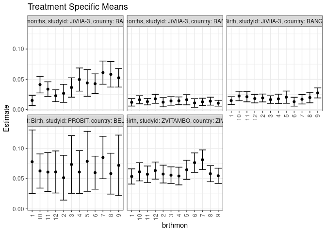

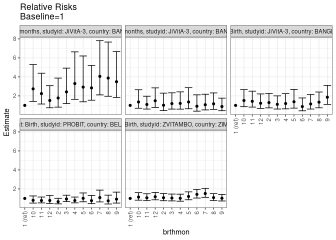

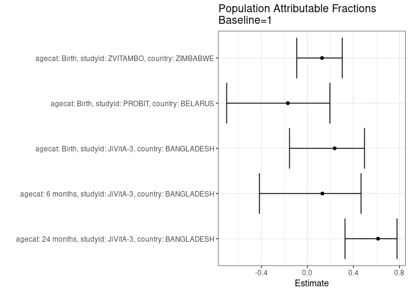

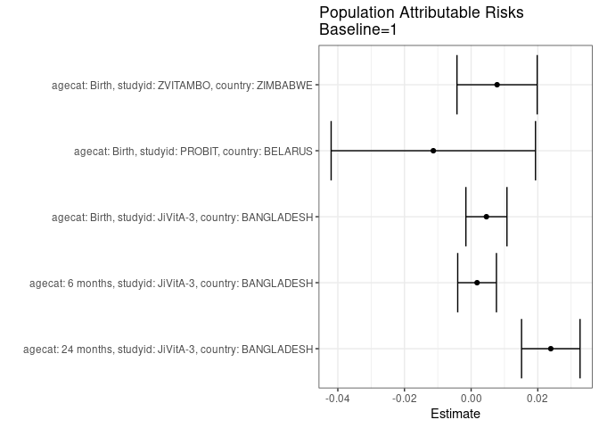

## Results Table

### Parameter: TSM

| agecat | studyid | country | intervention_level | baseline_level | estimate | ci_lower | ci_upper |
| --- | --- | --- | --- | --- | --- | --- | --- |
| Birth | JiVitA-3 | BANGLADESH | 1 | NA | 0.0147874 | 0.0083642 | 0.0212106 |
| Birth | JiVitA-3 | BANGLADESH | 2 | NA | 0.0191489 | 0.0126291 | 0.0256688 |
| Birth | JiVitA-3 | BANGLADESH | 3 | NA | 0.0164416 | 0.0101218 | 0.0227613 |
| Birth | JiVitA-3 | BANGLADESH | 4 | NA | 0.0176707 | 0.0099776 | 0.0253637 |
| Birth | JiVitA-3 | BANGLADESH | 5 | NA | 0.0204545 | 0.0103116 | 0.0305975 |
| Birth | JiVitA-3 | BANGLADESH | 6 | NA | 0.0129730 | 0.0056605 | 0.0202855 |
| Birth | JiVitA-3 | BANGLADESH | 7 | NA | 0.0169972 | 0.0091507 | 0.0248436 |
| Birth | JiVitA-3 | BANGLADESH | 8 | NA | 0.0198020 | 0.0111365 | 0.0284675 |
| Birth | JiVitA-3 | BANGLADESH | 9 | NA | 0.0274784 | 0.0192076 | 0.0357493 |
| Birth | JiVitA-3 | BANGLADESH | 10 | NA | 0.0224075 | 0.0145749 | 0.0302401 |
| Birth | JiVitA-3 | BANGLADESH | 11 | NA | 0.0211668 | 0.0127905 | 0.0295431 |
| Birth | JiVitA-3 | BANGLADESH | 12 | NA | 0.0181106 | 0.0110303 | 0.0251909 |
| Birth | PROBIT | BELARUS | 1 | NA | 0.0778589 | 0.0253996 | 0.1303182 |
| Birth | PROBIT | BELARUS | 2 | NA | 0.0514429 | 0.0144130 | 0.0884729 |
| Birth | PROBIT | BELARUS | 3 | NA | 0.0733262 | 0.0256655 | 0.1209870 |
| Birth | PROBIT | BELARUS | 4 | NA | 0.0608247 | 0.0253984 | 0.0962511 |
| Birth | PROBIT | BELARUS | 5 | NA | 0.0785563 | 0.0290070 | 0.1281056 |
| Birth | PROBIT | BELARUS | 6 | NA | 0.0598039 | 0.0325197 | 0.0870882 |
| Birth | PROBIT | BELARUS | 7 | NA | 0.0848249 | 0.0497250 | 0.1199248 |
| Birth | PROBIT | BELARUS | 8 | NA | 0.0581930 | 0.0244235 | 0.0919625 |
| Birth | PROBIT | BELARUS | 9 | NA | 0.0718608 | 0.0218615 | 0.1218601 |
| Birth | PROBIT | BELARUS | 10 | NA | 0.0625420 | 0.0343151 | 0.0907690 |
| Birth | PROBIT | BELARUS | 11 | NA | 0.0607375 | 0.0285901 | 0.0928849 |
| Birth | PROBIT | BELARUS | 12 | NA | 0.0609598 | 0.0262319 | 0.0956877 |
| Birth | ZVITAMBO | ZIMBABWE | 1 | NA | 0.0535280 | 0.0409640 | 0.0660920 |
| Birth | ZVITAMBO | ZIMBABWE | 2 | NA | 0.0574713 | 0.0427250 | 0.0722175 |
| Birth | ZVITAMBO | ZIMBABWE | 3 | NA | 0.0557103 | 0.0420117 | 0.0694089 |
| Birth | ZVITAMBO | ZIMBABWE | 4 | NA | 0.0542299 | 0.0396111 | 0.0688487 |
| Birth | ZVITAMBO | ZIMBABWE | 5 | NA | 0.0645856 | 0.0487794 | 0.0803918 |
| Birth | ZVITAMBO | ZIMBABWE | 6 | NA | 0.0763359 | 0.0602589 | 0.0924129 |
| Birth | ZVITAMBO | ZIMBABWE | 7 | NA | 0.0812044 | 0.0650326 | 0.0973762 |
| Birth | ZVITAMBO | ZIMBABWE | 8 | NA | 0.0580808 | 0.0447799 | 0.0713817 |
| Birth | ZVITAMBO | ZIMBABWE | 9 | NA | 0.0545746 | 0.0419617 | 0.0671875 |
| Birth | ZVITAMBO | ZIMBABWE | 10 | NA | 0.0612245 | 0.0462140 | 0.0762350 |
| Birth | ZVITAMBO | ZIMBABWE | 11 | NA | 0.0571170 | 0.0434211 | 0.0708128 |
| Birth | ZVITAMBO | ZIMBABWE | 12 | NA | 0.0632689 | 0.0491241 | 0.0774137 |
| 6 months | JiVitA-3 | BANGLADESH | 1 | NA | 0.0119225 | 0.0057159 | 0.0181291 |
| 6 months | JiVitA-3 | BANGLADESH | 2 | NA | 0.0121317 | 0.0045087 | 0.0197547 |
| 6 months | JiVitA-3 | BANGLADESH | 3 | NA | 0.0141945 | 0.0071317 | 0.0212572 |
| 6 months | JiVitA-3 | BANGLADESH | 4 | NA | 0.0144312 | 0.0079813 | 0.0208811 |
| 6 months | JiVitA-3 | BANGLADESH | 5 | NA | 0.0162162 | 0.0078034 | 0.0246290 |
| 6 months | JiVitA-3 | BANGLADESH | 6 | NA | 0.0108514 | 0.0037497 | 0.0179532 |
| 6 months | JiVitA-3 | BANGLADESH | 7 | NA | 0.0127490 | 0.0067604 | 0.0187376 |
| 6 months | JiVitA-3 | BANGLADESH | 8 | NA | 0.0138614 | 0.0073147 | 0.0204081 |
| 6 months | JiVitA-3 | BANGLADESH | 9 | NA | 0.0104874 | 0.0056538 | 0.0153209 |
| 6 months | JiVitA-3 | BANGLADESH | 10 | NA | 0.0162162 | 0.0095711 | 0.0228614 |
| 6 months | JiVitA-3 | BANGLADESH | 11 | NA | 0.0130756 | 0.0077310 | 0.0184202 |
| 6 months | JiVitA-3 | BANGLADESH | 12 | NA | 0.0177440 | 0.0103159 | 0.0251720 |
| 24 months | JiVitA-3 | BANGLADESH | 1 | NA | 0.0150376 | 0.0065061 | 0.0235691 |
| 24 months | JiVitA-3 | BANGLADESH | 2 | NA | 0.0267380 | 0.0117858 | 0.0416901 |
| 24 months | JiVitA-3 | BANGLADESH | 3 | NA | 0.0364146 | 0.0204289 | 0.0524002 |
| 24 months | JiVitA-3 | BANGLADESH | 4 | NA | 0.0496032 | 0.0305132 | 0.0686931 |
| 24 months | JiVitA-3 | BANGLADESH | 5 | NA | 0.0439560 | 0.0219593 | 0.0659528 |
| 24 months | JiVitA-3 | BANGLADESH | 6 | NA | 0.0426929 | 0.0264160 | 0.0589699 |
| 24 months | JiVitA-3 | BANGLADESH | 7 | NA | 0.0610119 | 0.0418540 | 0.0801698 |
| 24 months | JiVitA-3 | BANGLADESH | 8 | NA | 0.0582524 | 0.0371450 | 0.0793599 |
| 24 months | JiVitA-3 | BANGLADESH | 9 | NA | 0.0525000 | 0.0371451 | 0.0678549 |
| 24 months | JiVitA-3 | BANGLADESH | 10 | NA | 0.0411899 | 0.0274588 | 0.0549210 |
| 24 months | JiVitA-3 | BANGLADESH | 11 | NA | 0.0336862 | 0.0215250 | 0.0458475 |
| 24 months | JiVitA-3 | BANGLADESH | 12 | NA | 0.0228233 | 0.0130096 | 0.0326371 |

### Parameter: E(Y)

| agecat | studyid | country | intervention_level | baseline_level | estimate | ci_lower | ci_upper |
| --- | --- | --- | --- | --- | --- | --- | --- |
| Birth | JiVitA-3 | BANGLADESH | NA | NA | 0.0193738 | 0.0169653 | 0.0217823 |
| Birth | PROBIT | BELARUS | NA | NA | 0.0665123 | 0.0333611 | 0.0996634 |
| Birth | ZVITAMBO | ZIMBABWE | NA | NA | 0.0613145 | 0.0571772 | 0.0654519 |
| 6 months | JiVitA-3 | BANGLADESH | NA | NA | 0.0137035 | 0.0116269 | 0.0157801 |
| 24 months | JiVitA-3 | BANGLADESH | NA | NA | 0.0389399 | 0.0346167 | 0.0432631 |

### Parameter: RR

| agecat | studyid | country | intervention_level | baseline_level | estimate | ci_lower | ci_upper |
| --- | --- | --- | --- | --- | --- | --- | --- |
| Birth | JiVitA-3 | BANGLADESH | 1 | 1 | 1.0000000 | 1.0000000 | 1.000000 |
| Birth | JiVitA-3 | BANGLADESH | 2 | 1 | 1.2949468 | 0.7396923 | 2.267006 |
| Birth | JiVitA-3 | BANGLADESH | 3 | 1 | 1.1118614 | 0.6165585 | 2.005059 |
| Birth | JiVitA-3 | BANGLADESH | 4 | 1 | 1.1949799 | 0.6386303 | 2.235999 |
| Birth | JiVitA-3 | BANGLADESH | 5 | 1 | 1.3832386 | 0.7131840 | 2.682827 |
| Birth | JiVitA-3 | BANGLADESH | 6 | 1 | 0.8772973 | 0.4316406 | 1.783082 |
| Birth | JiVitA-3 | BANGLADESH | 7 | 1 | 1.1494334 | 0.6147198 | 2.149267 |
| Birth | JiVitA-3 | BANGLADESH | 8 | 1 | 1.3391089 | 0.7451009 | 2.406671 |
| Birth | JiVitA-3 | BANGLADESH | 9 | 1 | 1.8582301 | 1.1104799 | 3.109484 |
| Birth | JiVitA-3 | BANGLADESH | 10 | 1 | 1.5153075 | 0.8631048 | 2.660345 |
| Birth | JiVitA-3 | BANGLADESH | 11 | 1 | 1.4314017 | 0.8211211 | 2.495260 |
| Birth | JiVitA-3 | BANGLADESH | 12 | 1 | 1.2247308 | 0.6794311 | 2.207679 |
| Birth | PROBIT | BELARUS | 1 | 1 | 1.0000000 | 1.0000000 | 1.000000 |
| Birth | PROBIT | BELARUS | 2 | 1 | 0.6607199 | 0.4303238 | 1.014470 |
| Birth | PROBIT | BELARUS | 3 | 1 | 0.9417840 | 0.6622193 | 1.339371 |
| Birth | PROBIT | BELARUS | 4 | 1 | 0.7812178 | 0.5330074 | 1.145015 |
| Birth | PROBIT | BELARUS | 5 | 1 | 1.0089570 | 0.6459226 | 1.576031 |
| Birth | PROBIT | BELARUS | 6 | 1 | 0.7681066 | 0.4484557 | 1.315599 |
| Birth | PROBIT | BELARUS | 7 | 1 | 1.0894698 | 0.6337318 | 1.872945 |
| Birth | PROBIT | BELARUS | 8 | 1 | 0.7474158 | 0.4154466 | 1.344650 |
| Birth | PROBIT | BELARUS | 9 | 1 | 0.9229624 | 0.5125199 | 1.662100 |
| Birth | PROBIT | BELARUS | 10 | 1 | 0.8032742 | 0.5109731 | 1.262785 |
| Birth | PROBIT | BELARUS | 11 | 1 | 0.7800976 | 0.5300002 | 1.148211 |
| Birth | PROBIT | BELARUS | 12 | 1 | 0.7829523 | 0.4625852 | 1.325192 |
| Birth | ZVITAMBO | ZIMBABWE | 1 | 1 | 1.0000000 | 1.0000000 | 1.000000 |
| Birth | ZVITAMBO | ZIMBABWE | 2 | 1 | 1.0736677 | 0.7583069 | 1.520179 |
| Birth | ZVITAMBO | ZIMBABWE | 3 | 1 | 1.0407698 | 0.7408383 | 1.462130 |
| Birth | ZVITAMBO | ZIMBABWE | 4 | 1 | 1.0131138 | 0.7086396 | 1.448408 |
| Birth | ZVITAMBO | ZIMBABWE | 5 | 1 | 1.2065760 | 0.8595811 | 1.693645 |
| Birth | ZVITAMBO | ZIMBABWE | 6 | 1 | 1.4260930 | 1.0403774 | 1.954811 |
| Birth | ZVITAMBO | ZIMBABWE | 7 | 1 | 1.5170455 | 1.1151006 | 2.063874 |
| Birth | ZVITAMBO | ZIMBABWE | 8 | 1 | 1.0850551 | 0.7816902 | 1.506152 |
| Birth | ZVITAMBO | ZIMBABWE | 9 | 1 | 1.0195535 | 0.7334195 | 1.417319 |
| Birth | ZVITAMBO | ZIMBABWE | 10 | 1 | 1.1437848 | 0.8145894 | 1.606016 |
| Birth | ZVITAMBO | ZIMBABWE | 11 | 1 | 1.0670485 | 0.7628852 | 1.492482 |
| Birth | ZVITAMBO | ZIMBABWE | 12 | 1 | 1.1819780 | 0.8547359 | 1.634507 |
| 6 months | JiVitA-3 | BANGLADESH | 1 | 1 | 1.0000000 | 1.0000000 | 1.000000 |
| 6 months | JiVitA-3 | BANGLADESH | 2 | 1 | 1.0175477 | 0.4526386 | 2.287484 |
| 6 months | JiVitA-3 | BANGLADESH | 3 | 1 | 1.1905607 | 0.6100720 | 2.323389 |
| 6 months | JiVitA-3 | BANGLADESH | 4 | 1 | 1.2104202 | 0.6041013 | 2.425284 |
| 6 months | JiVitA-3 | BANGLADESH | 5 | 1 | 1.3601351 | 0.6459664 | 2.863876 |
| 6 months | JiVitA-3 | BANGLADESH | 6 | 1 | 0.9101628 | 0.3920957 | 2.112740 |
| 6 months | JiVitA-3 | BANGLADESH | 7 | 1 | 1.0693227 | 0.5258902 | 2.174315 |
| 6 months | JiVitA-3 | BANGLADESH | 8 | 1 | 1.1626238 | 0.5842250 | 2.313653 |
| 6 months | JiVitA-3 | BANGLADESH | 9 | 1 | 0.8796268 | 0.4392935 | 1.761336 |
| 6 months | JiVitA-3 | BANGLADESH | 10 | 1 | 1.3601351 | 0.6988876 | 2.647017 |
| 6 months | JiVitA-3 | BANGLADESH | 11 | 1 | 1.0967169 | 0.6124994 | 1.963737 |
| 6 months | JiVitA-3 | BANGLADESH | 12 | 1 | 1.4882763 | 0.7782042 | 2.846253 |
| 24 months | JiVitA-3 | BANGLADESH | 1 | 1 | 1.0000000 | 1.0000000 | 1.000000 |
| 24 months | JiVitA-3 | BANGLADESH | 2 | 1 | 1.7780749 | 0.8159794 | 3.874547 |
| 24 months | JiVitA-3 | BANGLADESH | 3 | 1 | 2.4215686 | 1.1919848 | 4.919521 |
| 24 months | JiVitA-3 | BANGLADESH | 4 | 1 | 3.2986111 | 1.6399881 | 6.634704 |
| 24 months | JiVitA-3 | BANGLADESH | 5 | 1 | 2.9230769 | 1.3779218 | 6.200917 |
| 24 months | JiVitA-3 | BANGLADESH | 6 | 1 | 2.8390805 | 1.5458671 | 5.214147 |
| 24 months | JiVitA-3 | BANGLADESH | 7 | 1 | 4.0572917 | 2.1077982 | 7.809863 |
| 24 months | JiVitA-3 | BANGLADESH | 8 | 1 | 3.8737864 | 1.9578935 | 7.664473 |
| 24 months | JiVitA-3 | BANGLADESH | 9 | 1 | 3.4912500 | 1.8286858 | 6.665348 |
| 24 months | JiVitA-3 | BANGLADESH | 10 | 1 | 2.7391304 | 1.4152886 | 5.301276 |
| 24 months | JiVitA-3 | BANGLADESH | 11 | 1 | 2.2401347 | 1.1440633 | 4.386299 |
| 24 months | JiVitA-3 | BANGLADESH | 12 | 1 | 1.5177515 | 0.7494850 | 3.073537 |

### Parameter: PAR

| agecat | studyid | country | intervention_level | baseline_level | estimate | ci_lower | ci_upper |
| --- | --- | --- | --- | --- | --- | --- | --- |
| Birth | JiVitA-3 | BANGLADESH | 1 | NA | 0.0045864 | -0.0015741 | 0.0107469 |
| Birth | PROBIT | BELARUS | 1 | NA | -0.0113466 | -0.0420058 | 0.0193126 |
| Birth | ZVITAMBO | ZIMBABWE | 1 | NA | 0.0077866 | -0.0042482 | 0.0198213 |
| 6 months | JiVitA-3 | BANGLADESH | 1 | NA | 0.0017810 | -0.0040277 | 0.0075898 |
| 24 months | JiVitA-3 | BANGLADESH | 1 | NA | 0.0239023 | 0.0151282 | 0.0326765 |

### Parameter: PAF

| agecat | studyid | country | intervention_level | baseline_level | estimate | ci_lower | ci_upper |
| --- | --- | --- | --- | --- | --- | --- | --- |
| Birth | JiVitA-3 | BANGLADESH | 1 | NA | 0.2367313 | -0.1560394 | 0.4960560 |
| Birth | PROBIT | BELARUS | 1 | NA | -0.1705943 | -0.7024063 | 0.1950858 |
| Birth | ZVITAMBO | ZIMBABWE | 1 | NA | 0.1269938 | -0.0928937 | 0.3026404 |
| 6 months | JiVitA-3 | BANGLADESH | 1 | NA | 0.1299682 | -0.4175735 | 0.4660204 |
| 24 months | JiVitA-3 | BANGLADESH | 1 | NA | 0.6138256 | 0.3264386 | 0.7785938 |